# R Notebook

```r
library(tidyverse)
library(ggplot2)
library(janitor)
library(dplyr)
library(infer)
```

1.1 Hypothesis testing - practical

```r
data(msleep)
msleep
```

| name | genus | vore | order | conservation | sleep_total | sleep_rem | sleep_cycle | awake | brainwt | bodywt |
| --- | --- | --- | --- | --- | --- | --- | --- | --- | --- | --- |
| Cheetah | Acinonyx | carni | Carnivora | lc | 12.1 | NA | NA | 11.90 | NA | 50.000 |
| Owl monkey | Aotus | omni | Primates | NA | 17.0 | 1.8 | NA | 7.00 | 0.01550 | 0.480 |
| Mountain beaver | Aplodontia | herbi | Rodentia | nt | 14.4 | 2.4 | NA | 9.60 | NA | 1.350 |
| Greater short-tailed shrew | Blarina | omni | Soricomorpha | lc | 14.9 | 2.3 | 0.1333333 | 9.10 | 0.00029 | 0.019 |
| Cow | Bos | herbi | Artiodactyla | domesticated | 4.0 | 0.7 | 0.6666667 | 20.00 | 0.42300 | 600.000 |
| Three-toed sloth | Bradypus | herbi | Pilosa | NA | 14.4 | 2.2 | 0.7666667 | 9.60 | NA | 3.850 |
| Northern fur seal | Callorhinus | carni | Carnivora | vu | 8.7 | 1.4 | 0.3833333 | 15.30 | NA | 20.490 |
| Vesper mouse | Calomys | NA | Rodentia | NA | 7.0 | NA | NA | 17.00 | NA | 0.045 |
| Dog | Canis | carni | Carnivora | domesticated | 10.1 | 2.9 | 0.3333333 | 13.90 | 0.07000 | 14.000 |
| Roe deer | Capreolus | herbi | Artiodactyla | lc | 3.0 | NA | NA | 21.00 | 0.09820 | 14.800 |

[output cut: 73 more lines]

Q1. Explore the dataset and familiarise yourself with it

```r
glimpse(msleep)
```

```
Rows: 83
Columns: 11
$ name         <chr> "Cheetah", "Owl monkey", "Mountain beaver", "Greater short-tailed shrew", "Cow", "Three-t…
$ genus        <chr> "Acinonyx", "Aotus", "Aplodontia", "Blarina", "Bos", "Bradypus", "Callorhinus", "Calomys"…
$ vore         <chr> "carni", "omni", "herbi", "omni", "herbi", "herbi", "carni", NA, "carni", "herbi", "herbi…
$ order        <chr> "Carnivora", "Primates", "Rodentia", "Soricomorpha", "Artiodactyla", "Pilosa", "Carnivora…
$ conservation <chr> "lc", NA, "nt", "lc", "domesticated", NA, "vu", NA, "domesticated", "lc", "lc", "domestic…
$ sleep_total  <dbl> 12.1, 17.0, 14.4, 14.9, 4.0, 14.4, 8.7, 7.0, 10.1, 3.0, 5.3, 9.4, 10.0, 12.5, 10.3, 8.3, …
$ sleep_rem    <dbl> NA, 1.8, 2.4, 2.3, 0.7, 2.2, 1.4, NA, 2.9, NA, 0.6, 0.8, 0.7, 1.5, 2.2, 2.0, 1.4, 3.1, 0.…
$ sleep_cycle  <dbl> NA, NA, NA, 0.1333333, 0.6666667, 0.7666667, 0.3833333, NA, 0.3333333, NA, NA, 0.2166667,…
$ awake        <dbl> 11.90, 7.00, 9.60, 9.10, 20.00, 9.60, 15.30, 17.00, 13.90, 21.00, 18.70, 14.60, 14.00, 11…
$ brainwt      <dbl> NA, 0.01550, NA, 0.00029, 0.42300, NA, NA, NA, 0.07000, 0.09820, 0.11500, 0.00550, NA, 0.…
$ bodywt       <dbl> 50.000, 0.480, 1.350, 0.019, 600.000, 3.850, 20.490, 0.045, 14.000, 14.800, 33.500, 0.728…
```

```r
view(msleep)
```

```r
head(msleep)
```

| name | genus | vore | order | conservation | sleep_total | sleep_rem | sleep_cycle | awake | brainwt | bodywt |
| --- | --- | --- | --- | --- | --- | --- | --- | --- | --- | --- |
| Cheetah | Acinonyx | carni | Carnivora | lc | 12.1 | NA | NA | 11.9 | NA | 50.000 |
| Owl monkey | Aotus | omni | Primates | NA | 17.0 | 1.8 | NA | 7.0 | 0.01550 | 0.480 |
| Mountain beaver | Aplodontia | herbi | Rodentia | nt | 14.4 | 2.4 | NA | 9.6 | NA | 1.350 |
| Greater short-tailed shrew | Blarina | omni | Soricomorpha | lc | 14.9 | 2.3 | 0.1333333 | 9.1 | 0.00029 | 0.019 |
| Cow | Bos | herbi | Artiodactyla | domesticated | 4.0 | 0.7 | 0.6666667 | 20.0 | 0.42300 | 600.000 |
| Three-toed sloth | Bradypus | herbi | Pilosa | NA | 14.4 | 2.2 | 0.7666667 | 9.6 | NA | 3.850 |

```r
NA
```

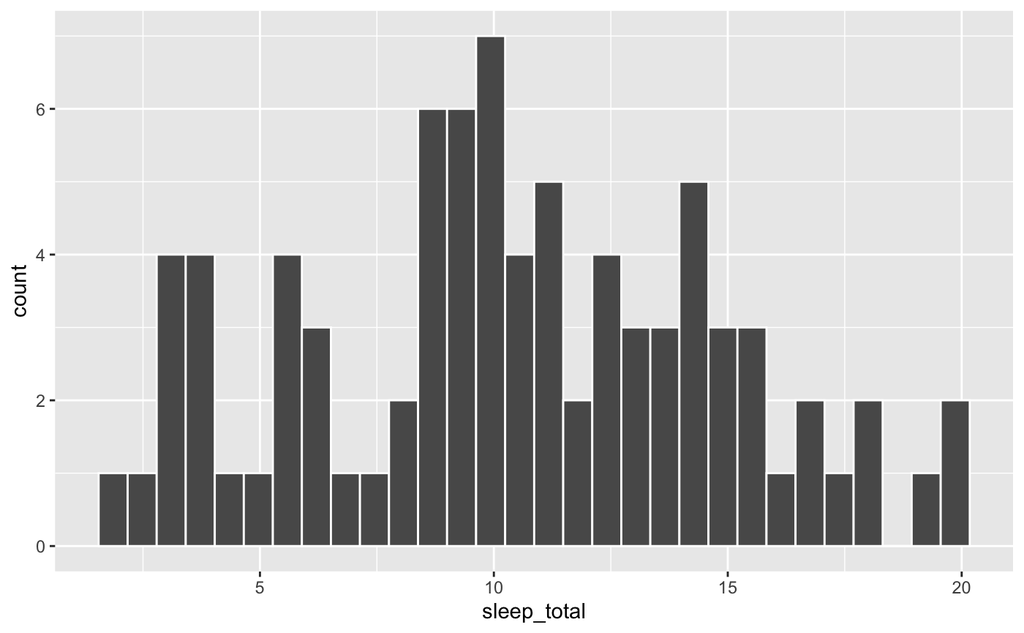

```r
msleep %>%
  ggplot(aes(x = sleep_total)) +
  geom_histogram(col = "white", bins = 30)
```

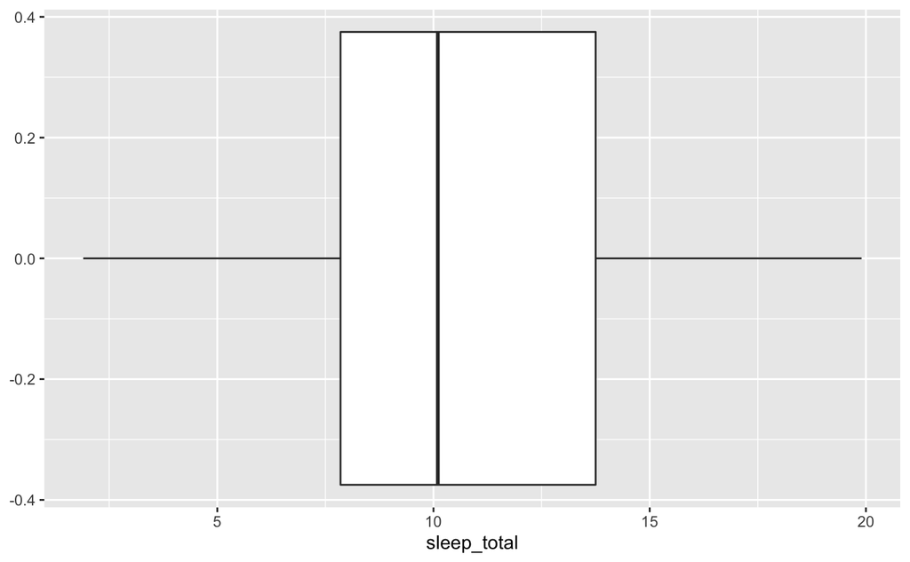

```r
msleep %>%
  ggplot(aes(x = sleep_total)) +
  geom_boxplot()
```

```r
msleep %>%
  summarise(mean_sleep_total = mean(sleep_total))
```

| mean_sleep_total |
| --- |
| 10.43373 |

```r
NA
```

```r
herbi_sleep_total <- msleep %>%
  filter(vore == "herbi") %>%
  select(name, sleep_total)
herbi_sleep_total
```

| name | sleep_total |
| --- | --- |
| Mountain beaver | 14.4 |
| Cow | 4.0 |
| Three-toed sloth | 14.4 |
| Roe deer | 3.0 |
| Goat | 5.3 |
| Guinea pig | 9.4 |
| Chinchilla | 12.5 |
| Tree hyrax | 5.3 |
| Asian elephant | 3.9 |
| Horse | 2.9 |

[output cut: 22 more lines]

```r
herbi_stats <- msleep %>%
  filter(vore == "herbi") %>%
  summarise(
    count = n(),
    mean = mean(sleep_total),
    sd = sd(sleep_total)
  )
herbi_stats
```

| count | mean | sd |
| --- | --- | --- |
| 32 | 9.509375 | 4.878746 |

```r
NA
```

```r
omni_sleep_total <- msleep %>%
  filter(vore == "omni") %>%
  select(name, sleep_total)
omni_sleep_total
```

| name | sleep_total |
| --- | --- |
| Owl monkey | 17.0 |
| Greater short-tailed shrew | 14.9 |
| Grivet | 10.0 |
| Star-nosed mole | 10.3 |
| African giant pouched rat | 8.3 |
| Lesser short-tailed shrew | 9.1 |
| North American Opossum | 18.0 |
| European hedgehog | 10.1 |
| Patas monkey | 10.9 |
| Galago | 9.8 |

[output cut: 10 more lines]

```r
omni_stats <- msleep %>%
  filter(vore == "omni") %>%
  summarise(
    count = n(),
    mean = mean(sleep_total),
    sd = sd(sleep_total)
  )
omni_stats
```

| count | mean | sd |
| --- | --- | --- |
| 20 | 10.925 | 2.949019 |

```r
msleep_dist <- msleep %>%
  tabyl(conservation)
msleep_dist
```

```
 conservation  n    percent valid_percent
           cd  2 0.02409639    0.03703704
 domesticated 10 0.12048193    0.18518519
           en  4 0.04819277    0.07407407
           lc 27 0.32530120    0.50000000
           nt  4 0.04819277    0.07407407
           vu  7 0.08433735    0.12962963
         <NA> 29 0.34939759            NA
```

```r
is_domesticated_msleep <- msleep %>%
  mutate(is_domesticated_msleep = ifelse(conservation == "domesticated", 1, 0))

is_domesticated_msleep
```

| name | genus | vore | order | conservation | sleep_total | sleep_rem | sleep_cycle | awake | brainwt | bodywt | is_domesticated_msleep |
| --- | --- | --- | --- | --- | --- | --- | --- | --- | --- | --- | --- |
| Cheetah | Acinonyx | carni | Carnivora | lc | 12.1 | NA | NA | 11.90 | NA | 50.000 | 0 |
| Owl monkey | Aotus | omni | Primates | NA | 17.0 | 1.8 | NA | 7.00 | 0.01550 | 0.480 | NA |
| Mountain beaver | Aplodontia | herbi | Rodentia | nt | 14.4 | 2.4 | NA | 9.60 | NA | 1.350 | 0 |
| Greater short-tailed shrew | Blarina | omni | Soricomorpha | lc | 14.9 | 2.3 | 0.1333333 | 9.10 | 0.00029 | 0.019 | 0 |
| Cow | Bos | herbi | Artiodactyla | domesticated | 4.0 | 0.7 | 0.6666667 | 20.00 | 0.42300 | 600.000 | 1 |
| Three-toed sloth | Bradypus | herbi | Pilosa | NA | 14.4 | 2.2 | 0.7666667 | 9.60 | NA | 3.850 | NA |
| Northern fur seal | Callorhinus | carni | Carnivora | vu | 8.7 | 1.4 | 0.3833333 | 15.30 | NA | 20.490 | 0 |
| Vesper mouse | Calomys | NA | Rodentia | NA | 7.0 | NA | NA | 17.00 | NA | 0.045 | NA |
| Dog | Canis | carni | Carnivora | domesticated | 10.1 | 2.9 | 0.3333333 | 13.90 | 0.07000 | 14.000 | 1 |
| Roe deer | Capreolus | herbi | Artiodactyla | lc | 3.0 | NA | NA | 21.00 | 0.09820 | 14.800 | 0 |

[output cut: 73 more lines]

```r
NA
```

ifelse(“domestic”, 1, 0)

```r
bootstrap_msleep <- is_domesticated_msleep %>%
  specify(response = is_domesticated_msleep) %>%
  generate(reps = 10000, type = "bootstrap") %>%
  calculate(stat = "mean")
```

```
Removed 29 rows containing missing values.
```

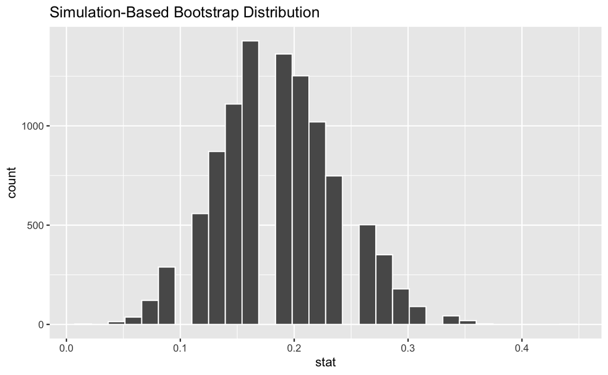

```r
bootstrap_msleep %>%
  visualise(bins = 30)
```

```r
msleep_ci95 <- bootstrap_msleep %>%
  get_ci(level = 0.05, type = "percentile")
msleep_ci95
```

| lower_ci | upper_ci |
| --- | --- |
| 0.1851852 | 0.1851852 |

1.2 Hypothesis testing - interpretation 1.2.1 Defining the Hypothesis For the following three business problems write out H0 and Ha in both mathematical notation and in words. Also state the method you would use to generate the null distribution (bootstrap, permutation or simulation). 1. You work for a independent coffee shop. You’ve performed a small survey in the local town and found that 40% of the people you randomly asked were aware of your shop in the town. You then conduct a marketing campaign by flyering local venues and targeting advertisements on social media. Finally you conduct a second small random survey in the town, asking if people are aware of your coffee shop. You want to test the hypothesis that the campaign has significantly increased awareness of the shop.

The test is a one-sample test for proportion, the initial findings were that 40% of the town were aware of the shop. For the flyering and advertising to have successfullly increased the awareness of the coffee shop the second small random survey findings would show an increase in awareness.

I’d use bootstrap to create the distribution

To define the Significance level: 0.05 (alpha), calculated p-value: 0.07

First we need to calculate the statistic we are interested in = number of people awae of the coffee shop/ total number of people surveyed.

Coffee shop problem. Significance level: 0.05, calculated p-value: 0.07

2. You work for a website design company and have performed an A/B test on the position of a banner on a website page promoting a particular item.

In the current test, the first group continues to be shown the banner at the right hand side of the webpage (its usual position) while the test group is shown it at the top of the page. The performance metric we will be testing is click through rate (CTR) on the banner, i.e. what proportion of users click on the banner

I’d use simulate to create the distribution

Website company problem. Significance level: 0.01, p-value: 0.006

3. You work as an analyst for a car manufacturing company - they have specific standards they must meet for standards and regulation purposes. You have been asked to check the quality control of the manufacture of a particular car part. The part must have a width of 145mm, with a small (given) level of tolerance. You have been given data on a sample of 1,000 parts produced over the period of a week.

Manufacturing company problem. Significance level: 0.05, p-value: 0.55